# Simulating Correlated Random Walks for the S&P 500

Previously I showed how to [simulate correlated random walks](https://mktstk.com/2015/01/05/simulating-correlated-random-walks-with-copulas/) using copulas on my blog, MKTSTK.com.

I was really thinking about the application to pairs trading back then, because one of the limitations of that implementation was that the method could only simulate *two* random variables at a time. If you wanted to do some large universe like the S&P 500 you had to do everything pairwise, and then you weren't really capturing any higher dimension relationships within the market.

The solution I found in another, more intuitive model, is the [KernelDesnityEstimator](https://slicematrix.github.io/python-docs/slicematrixIO.html#module-slicematrixIO.distributions) (KDE). This method allows for simulation of an arbitrary number of random variables, such as 500. This makes it much more flexible for simulation of trading strategies and modeling market risk.

Outline of notebook:

1. get sp500 data
2. train kde with data
3. simulate a years worth of data
4. compare correlation matrices
   - heatmaps
   - correlation filtered graphs

Est time to run: < 5 mins

To begin, let's fire up a client in our data center. Remember to substitute your api key in the code below.

Don't have a key yet? **[Get your api key here](http://www.slicematrix.com/pricing/)**

```python
from slicematrixIO import SliceMatrix

sm = SliceMatrix(api_key)
```

Next let's import some useful packages...

```python
import pandas as pd
from pandas_datareader import data as web
import datetime as dt
import numpy as np
```

I want to look in particular at the last year's worth of price data. I'm going to download the list of symbols for the S&P 500 from Quandl. Its cool we can do this directly from Amazon's S3 using pandas:

```python
start = dt.datetime(2016, 3, 15)
end = dt.datetime(2017, 3, 15)

data = pd.read_csv("https://s3.amazonaws.com/static.quandl.com/tickers/SP500.csv")
```

Then we can download the daily price data from Yahoo. Since its so many symbols (and some are going to fail because the symbol list is a few months stale) we'll print out successes and failures...

```python
# get the price data
volume = []
closes = []
good_tickers = []
for ticker in data['ticker'].values.tolist():
    print ticker,
    try:
        vdata = web.DataReader(ticker, 'yahoo', start, end)
        cdata = vdata[['Close']]
        closes.append(cdata)
        vdata = vdata[['Volume']]
        volume.append(vdata)
        good_tickers.append(ticker)
    except:
        print "x",
```

[output not shown]

Now we can combine the individual stock's closing price data into one dataframe, then we can take the log differences so we are simulating price *changes*

```python
closes = pd.concat(closes, axis = 1)
closes.columns = good_tickers

diffs = np.log(closes).diff().dropna(axis = 0, how = "all").dropna(axis = 1, how = "any")
diffs.head()
```

| Date | MMM | ABT | ABBV | ACN | ATVI | ADBE | AAP | AES | AET | AFL | ... | XEL | XRX | XLNX | XL | XYL | YHOO | YUM | ZBH | ZION | ZTS |
| --- | --- | --- | --- | --- | --- | --- | --- | --- | --- | --- | --- | --- | --- | --- | --- | --- | --- | --- | --- | --- | --- |
| 2016-03-16 | 0.002951 | 0.006993 | 0.012329 | 0.004845 | 0.009499 | 0.015315 | 0.002393 | 0.037572 | 0.004332 | 0.014676 | ... | 0.010317 | 0.002837 | 0.012459 | -0.004748 | 0.012766 | 0.022299 | 0.005354 | -0.000479 | -0.001209 | -0.006406 |
| 2016-03-17 | 0.005266 | 0.002734 | -0.017738 | 0.008975 | -0.005811 | 0.020098 | -0.006437 | 0.012217 | -0.025101 | 0.014780 | ... | 0.014075 | 0.010334 | -0.012884 | 0.016107 | 0.009789 | 0.007908 | 0.001778 | -0.006447 | 0.008432 | -0.018459 |
| 2016-03-18 | 0.009603 | 0.012334 | 0.022344 | -0.007304 | -0.012346 | 0.037740 | -0.002980 | 0.007775 | 0.018463 | 0.002049 | ... | -0.010659 | 0.005592 | 0.009100 | 0.012865 | 0.011723 | 0.025631 | -0.006111 | 0.008842 | 0.007965 | 0.028297 |
| 2016-03-21 | -0.002968 | -0.000736 | -0.009949 | 0.003612 | -0.004981 | -0.009897 | 0.007213 | -0.006908 | -0.010713 | -0.003786 | ... | -0.000244 | -0.009337 | 0.000421 | 0.001630 | -0.001268 | 0.008494 | 0.014201 | -0.001245 | 0.007115 | 0.018429 |
| 2016-03-22 | 0.000425 | 0.006602 | 0.026255 | -0.003056 | 0.015485 | 0.000648 | -0.002652 | 0.000000 | 0.009914 | 0.000948 | ... | -0.006844 | 0.003745 | 0.001683 | 0.002170 | -0.000507 | -0.001693 | -0.005681 | 0.000287 | -0.001577 | 0.026788 |

5 rows × 479 columns

SliceMatrix-IO will use the daily log price change data to train a Kernel Density Estimator:

```python
kde = sm.KernelDensityEstimator(dataset = diffs)
```

From here its easy to simulate a year's worth of trading data (approx 250 trading days in a year)

```python
sim_data = kde.simulate(250)
```

```python
sim_data = pd.DataFrame(sim_data, index = diffs.columns).T
```

```python
sim_data.head()
```

|  | MMM | ABT | ABBV | ACN | ATVI | ADBE | AAP | AES | AET | AFL | ... | XEL | XRX | XLNX | XL | XYL | YHOO | YUM | ZBH | ZION | ZTS |
| --- | --- | --- | --- | --- | --- | --- | --- | --- | --- | --- | --- | --- | --- | --- | --- | --- | --- | --- | --- | --- | --- |
| 0 | 0.006159 | 0.007662 | 0.009268 | 0.012846 | 0.029493 | -0.002194 | 0.008525 | -0.000653 | -0.000636 | 0.018822 | ... | 0.007127 | -0.030757 | 0.001632 | -0.011515 | 0.014036 | 0.014358 | -0.013102 | 0.002392 | 0.002477 | 0.009678 |
| 1 | -0.002018 | 0.014994 | -0.010243 | 0.024916 | -0.009707 | 0.012144 | 0.004570 | 0.025307 | 0.019325 | -0.000195 | ... | 0.012077 | 0.007151 | 0.003383 | -0.026380 | 0.005627 | 0.028981 | 0.012425 | 0.002630 | -0.025116 | -0.004304 |
| 2 | 0.000193 | -0.012505 | -0.007895 | 0.006504 | -0.000856 | 0.009518 | -0.007657 | -0.019319 | -0.010091 | -0.016492 | ... | 0.007651 | -0.019429 | -0.014360 | 0.002130 | -0.012713 | -0.027744 | 0.012755 | 0.023383 | -0.021362 | -0.008379 |
| 3 | 0.012992 | 0.016534 | -0.002165 | 0.026241 | -0.016912 | -0.037794 | 0.043180 | -0.027637 | 0.003202 | 0.019111 | ... | -0.003606 | -0.015081 | -0.010234 | 0.001233 | 0.016993 | -0.021139 | -0.060853 | -0.012675 | 0.030996 | -0.017149 |
| 4 | 0.028327 | 0.021744 | 0.034191 | 0.026641 | 0.063421 | 0.033316 | -0.003978 | -0.016046 | 0.028354 | 0.013191 | ... | -0.012433 | 0.016448 | 0.055355 | 0.038266 | 0.053153 | 0.013385 | 0.048467 | 0.014084 | 0.060291 | 0.024805 |

5 rows × 479 columns

Traditionally, the humble heatmap has been the visualization of choice for traders / quants who want to visualize correlation matrices. While the heatmap is good for rendering small to moderately sized matrices, once you get hundreds of nodes it becomes hard to tell whats going on. For example:

```python
%matplotlib inline
import seaborn as sns
import matplotlib.pyplot as plt
```

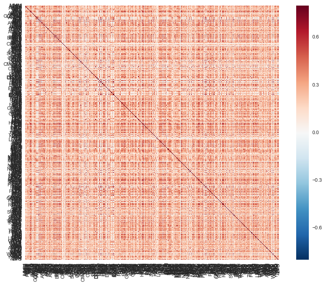

```python
f, ax = plt.subplots(figsize=(12, 9))

sns.heatmap(diffs.corr(), vmax=.8, square=True)
plt.show()
```

This produces a static image which is hard to get to look right in a small confined space. Even when you zoom in to a small scale, you lose the entire feel of the graph and what symbols are connected to what.

Luckily there are better tools at our disposal for the visualization of larger matrices: the network graph model. One such model which is particularly useful for analysis of time series data like the stock market is the Correlation Filtered Graph. This model is driven from the correlation matrix of the input data. This matrix is transformed into a distance and a nearest neighbors graph is drawn using that distance matrix.

The resulting graph can be plotted. From there we can verify that the simulated data is indeed representative of the original (real / observed) dataset.

Let's created two graphs, one using real data and one using the simulated data:

```python
cfg_real = sm.CorrelationFilteredGraph(dataset = diffs.T)
cfg_sim  = sm.CorrelationFilteredGraph(dataset = sim_data.T)
```

[slicematrixIO-python](https://slicematrix.github.io/python-docs/) has a module for rendering network graphs inside Jupyter Notebooks like this one. To begin let's so some initial setup for graphing the network models.

```python
from slicematrixIO.notebook import GraphEngine
viz = GraphEngine(sm)
```

```
initializing window.graph_data
```

```python
viz.init_style()
```

```python
viz.init_data()
```

Now we can render the graph models using a D3 force directed network graph visualization:

```python
viz.drawNetworkGraph(cfg_real, width = 950, height = 950, min_node_size = 6, charge = -50, color_map = "Winter", graph_layout = "force", label_color = "#000", graph_style = "white")
```

[output not shown]

```python
viz.drawNetworkGraph(cfg_sim, width = 950, height = 950, min_node_size = 6, charge = -50, color_map = "Winter", graph_layout = "force", label_color = "#000", graph_style = "white")
```

[output not shown]

```python
cfg_real.neighborhood("AAPL")
```

```
{u'AVGO': {u'weight': 0.48320809630633565},
 u'GOOG': {u'weight': 0.4263563496717201},
 u'GOOGL': {u'weight': 0.42263098020664097}}
```

```python
cfg_sim.neighborhood("AAPL")
```

```
{u'AVGO': {u'weight': 0.47731219367886335},
 u'GOOG': {u'weight': 0.4390895656012743},
 u'GOOGL': {u'weight': 0.43969453781368845}}
```

Don't have a key yet? **[Get your api key here](http://www.slicematrix.com/pricing/)**